# Géomatique avec R - Exercices

# Le package sf

1. Les données utilisées dans ce document sont stockées dans un projet RStudio. Vous devez le télécharger puis le décompresser sur votre machine. Il vous sera ensuite possible de tester l’ensemble des manipulations proposées dans ce document au sein du projet **geodata**.  
   [Télécharger le projet](https://rcarto.github.io/geomatique_avec_r/geodata.zip)
2. Nous utiliserons principalement le package `sf` dans la suite de ce document.  
   Installez le en utilisant la fonction `install.packages()`.

```r
install.packages("sf")
```

# Import et export

Importez la couche des restaurants depuis le fichier **lot.gpkg** dans un objet nommé “resto”.

```r
library(sf)
# inspecter le fichier pour connaître les couches disponibles
st_layers(dsn = "data/lot.gpkg")
```

```
#> Driver: GPKG
#> Available layers:
#>     layer_name geometry_type features fields              crs_name
#> 1     communes Multi Polygon      313     12 RGF93 v1 / Lambert-93
#> 2 departements Multi Polygon       96      5 RGF93 v1 / Lambert-93
#> 3  restaurants         Point      694      2 RGF93 v1 / Lambert-93
#> 4   elevations         Point     5228      1 RGF93 v1 / Lambert-93
#> 5       routes   Line String     1054      2 RGF93 v1 / Lambert-93
```

```r
# import de la couche des restaurants
resto <- st_read(dsn = "data/lot.gpkg", layer = "restaurants")
```

# Exploration et affichage

Affichez les communes et les restaurants sur une même carte.

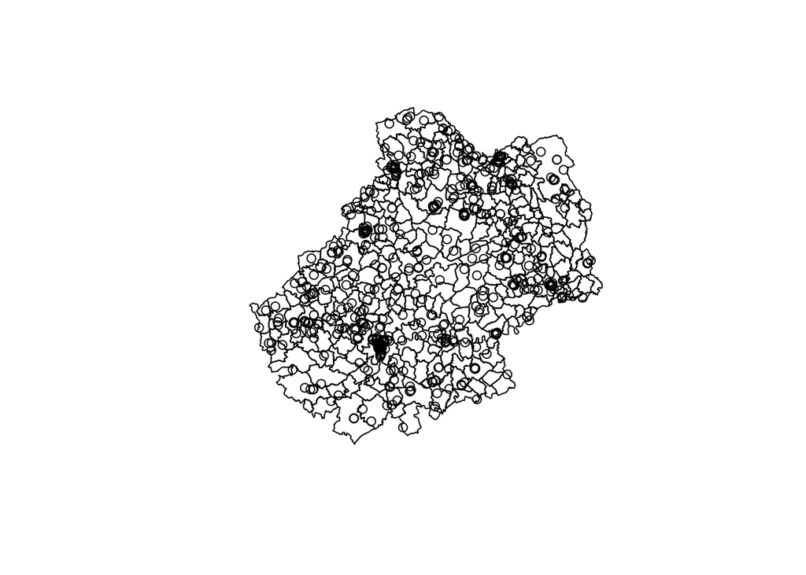

```r
# import des données
library(sf)
com <- st_read(dsn = "data/lot.gpkg", layer = "communes", quiet = TRUE)
resto <- st_read(dsn = "data/lot.gpkg", layer = "restaurants", quiet = TRUE)
# Avec le package sf
plot(st_geometry(com))
plot(st_geometry(resto), add = T)
```

```r
# Avec le package mapsf
# installation du package
install.packages("mapsf")
```

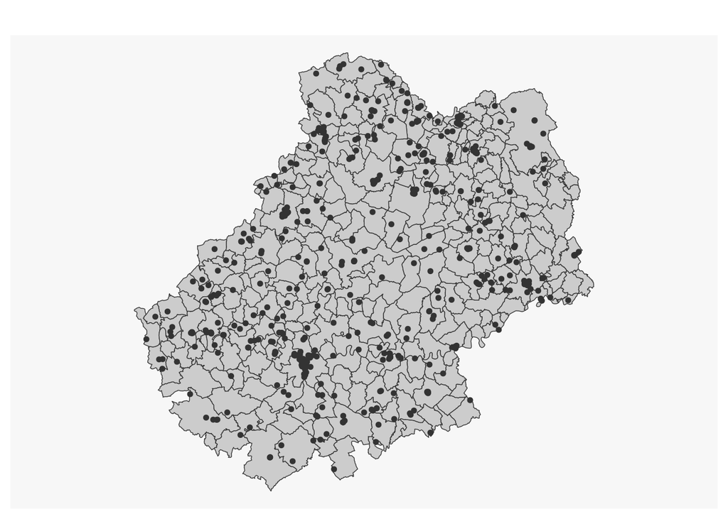

```r
library(mapsf)
mf_map(com)
mf_map(resto, add = T)
```

# Sélection et jointure attributaire

1. Importer la couche des communes du département du Lot à partir du fichier geopackage **lot.gpkg**.

```r
# import des données
library(sf)
com <- st_read(dsn = "data/lot.gpkg", layer = "communes", quiet = TRUE)
```

2. Importer le fichier **com.csv**.  
   Ce jeu de données porte sur les communes du Lot et contient plusieurs variables supplémentaires:
   - le nombre d’actifs (**ACT**).
   - le nombre d’actifs dans l’industrie (**IND**)
   - la part des actifs dans la population totale (**SACT**)
   - la part des actifs dans l’industrie dans le total des actifs (**SACT_IND**)

```r
# import de données supplémentaires
com_df <- read.csv(file = "data/com.csv")
```

3. Joindre le jeu de données et la couche des communes.

```r
# des identifiants en commun?
names(com_df)
```

```
#> [1] "INSEE_COM" "ACT"       "IND"       "SACT"      "SACT_IND"
```

```r
names(com)
```

```
#>  [1] "INSEE_COM"  "NOM_COM"    "STATUT"     "POPULATION" "AGR_H"
#>  [6] "AGR_F"      "IND_H"      "IND_F"      "BTP_H"      "BTP_F"
#> [11] "TER_H"      "TER_F"      "geom"
```

```r
# jointure attributaire
com_final <- merge(
  x = com,             # l'objet sf
  y = com_df,          # le data.frame
  by.x = "INSEE_COM",  # identifiant dans x
  by.y = "INSEE_COM",  # identifiant dans y
  all.x = TRUE         # conserver toutes les lignes
)
```

4. Sélectionnez les communes du Lot ayant plus de 500 actifs et dont la part des actifs dans la population totale est supérieure à 30%.

```r
# selection des communes
com_sel <- com_final[com_final$ACT > 500 & com_final$SACT > 30, ]
```

5. Affichez toutes les communes en gris et les communes sélectionnées en rouge.

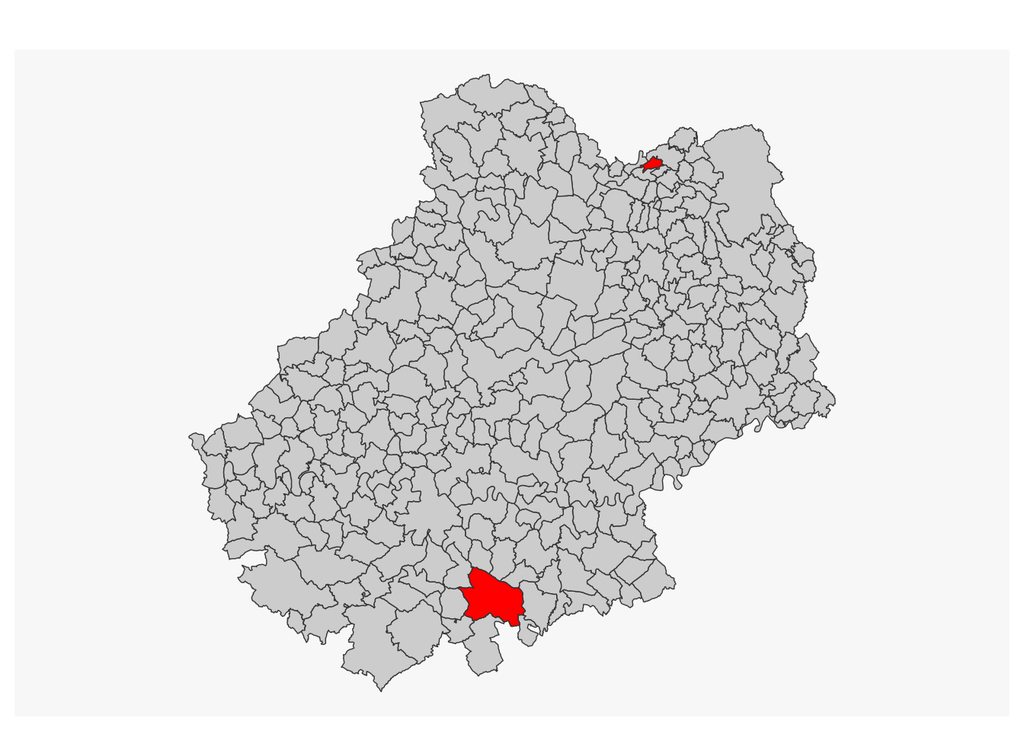

```r
# Affichage
library(mapsf)
mf_map(com)
mf_map(com_sel, col = "red", add = TRUE)
```

# Sélection et jointure spatiale

1. Importez la couche des communes et celle des restaurants du Lot.

```r
# import des données
library(sf)
com <- st_read(dsn = "data/lot.gpkg", layer = "communes", quiet = TRUE)
resto_raw <- st_read(dsn = "data/lot.gpkg", layer = "restaurants", quiet = TRUE)
```

2. Réaliser une jointure spatiale pour connaitre pour chaque restaurant le nom et l’identifiant de la commune dans laquelle il se trouve. `st_join()`

```r
# jointure spatiale
resto <- st_join(resto_raw, com[ ,c("INSEE_COM", "NOM_COM")], join = st_within)
head(resto, 3)
```

```
#> Simple feature collection with 3 features and 4 fields
#> Geometry type: POINT
#> Dimension:     XY
#> Bounding box:  xmin: 596050 ymin: 6365662 xmax: 611092.9 ymax: 6414950
#> Projected CRS: RGF93 v1 / Lambert-93
#>     id                      nom INSEE_COM   NOM_COM                     geom
#> 1  212             forest_cobra     46154 Laramière POINT (611092.9 6365662)
#> 2 2327 meteoropathologic_marlin     46003  Alvignac   POINT (596050 6414450)
#> 3 2328           pumice_unicorn     46003  Alvignac   POINT (596350 6414950)
```

# Opérations sur les géométries

1. Calculez le nombre de restaurants par commune.

```r
# import des données
library(sf)
com <- st_read(dsn = "data/lot.gpkg", layer = "communes", quiet = TRUE)
resto <- st_read(dsn = "data/lot.gpkg", layer = "restaurants", quiet = TRUE)

# liste des restaurants par communes
inter <- st_intersects(com, resto, sparse = TRUE)
inter
```

```
#> Sparse geometry binary predicate list of length 313, where the
#> predicate was `intersects'
#> first 10 elements:
#>  1: (empty)
#>  2: (empty)
#>  3: 2, 3, 4
#>  4: 5
#>  5: 6
#>  6: 7
#>  7: (empty)
#>  8: 8
#>  9: 9, 10, 11, 12, 13
#>  10: (empty)
```

```r
# compter le nombre de restaurants
com$n_resto <- lengths(inter)
```

2. Quelles communes ont plus de 10 restaurants et moins de 1000 habitants ?

```r
# sélection attributaire
com_sel <- com[com$n_resto > 10 & com$POPULATION < 1000, ]
com_sel$NOM_COM
```

```
#> [1] "Rocamadour"         "Saint-Cirq-Lapopie"
```

3. Créez une carte où vous afficherez toutes les communes en gris et les communes sélectionnées plus haut en rouge.

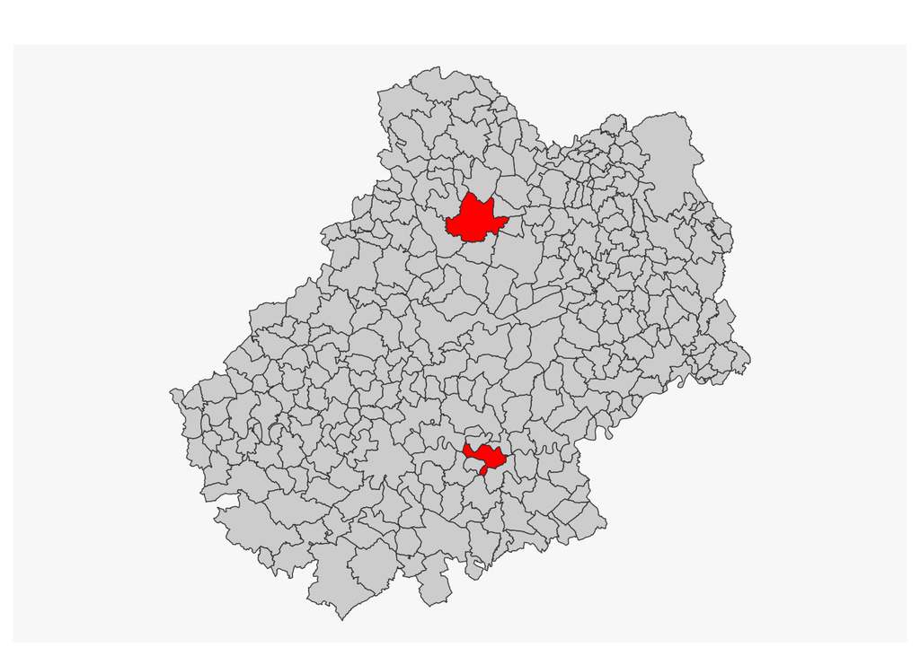

```r
library(mapsf)
mf_map(com)
mf_map(com_sel, col = "red", add = TRUE)
```